# Trabajo 1 Técnicas en aprendizaje estadístico

Camila Acosta Ramírez

Sergio Andrés Arboleda Zuluaga

Esteban Palacio Londoño

Natalia Ramírez Ossa

Carlos Alejandro Torres Albarracín

13/10/2020

## Introducción

La alta accidentalidad en Medellín se está convirtiendo en un problema de salud pública (Concejo de Medellín, 2020), los accidentes de tránsito aparecen como la séptima causa de morbilidad en el planeta y más aún, ha sido considerada como la segunda causa que más genera muertes en Colombia (Sistemas y Comunicaciones FODC, s.f.). Esta “epidemia” es la primera causa de muerte de las personas menores de 40 años a escala mundial. (ARL SURA, 2020)

Gracias a los datos abiertos presentados por la Alcaldía de Medellín, se puede acceder a las bases de datos de Movilidad de forma gratuita, donde muestra los Incidentes de Tránsito Georreferenciados por la Secretaria de Movilidad de la Alcaldía de Medellín, durante un periodo de tiempo de un año especifico. Entendiéndose por accidente de tránsito a un evento, generalmente involuntario, generado al menos por un vehículo en movimiento, que causa daños a personas y bienes involucrados en él, e igualmente afecta la normal circulación de los vehículos que se movilizan por la vía o vías comprendidas en el lugar o dentro de la zona de influencia del hecho (Alcaldía de Medellín, 2020).

El objetivo de este trabajo es que, a partir de técnicas en aprendizaje estadístico, se analicen, se modelen y se evalúen los datos (obtenidos como se mencionó anteriormente), para ello se realizó un análisis descriptivo y exploratorio de los datos, que permitió inferir y ver tendencias en el comportamiento de los mismos. Seguido de esto se crearon modelos estadísticos que predijeron la accidentalidad en Medellín diaria, semanal y mensual, en un periodo de tiempo de 4 años (Del año 2014 al 2017) y con el fin de identificar que los modelos se comportaran correctamente se evaluaron en los datos del año 2018. Finalmente se hizo un análisis de clasificación, donde se agruparon los diferentes barrios de la ciudad de Medellín (presentes en sus 16 comunas y 5 corregimientos) de acuerdo con su accidentalidad.

```r
#UNION DE BASES
datos <- rbind(datos_2014,datos_2015, datos_2016, datos_2017)

#ELIMINAR COLUMNAS INNECESARIAS
datos <- datos[,-c(1,2,4,22,21)]

#ARREGLO DE VARIABLE GRAVEDAD
datos$GRAVEDAD <- as.factor(datos$GRAVEDAD)

#ARREGLO VARIABLE CLASE
datos$CLASE <- str_replace_all(datos$CLASE,"^\\s|\\s$", "")
datos$CLASE <- str_replace_all(datos$CLASE, "Ca(í|i)da d?e? ?Ocupante",
                               "Caída Ocupante")
datos[datos$CLASE == "",6] <- "Otro"
datos$CLASE <- str_replace_all(datos$CLASE, "Choque y Atropello",
                               "Otro")
datos$CLASE <- as.factor(datos$CLASE)

#ARREGLO VARIABLE BARRIO
datos$BARRIO <- str_replace_all(datos$BARRIO, "(.\\sNo\\.)\\s?(\\d)$",
                                "\\1\\2")
datos$BARRIO <- str_replace_all(datos$BARRIO, "B. Cerro ? ?El Volador",
                                "B. Cerro El Volador")
datos$BARRIO <- str_replace_all(datos$BARRIO, "Barrios? de Jesús",
                                "Barrios de Jesús")
datos$BARRIO <- str_replace_all(datos$BARRIO, "Berl(í|i)n", "Berlín")
datos$BARRIO <- str_replace_all(datos$BARRIO, "L?a? ?Loma de (L|l)os Bernal",
                                "La Loma de Los Bernal")
datos$BARRIO <- str_replace_all(datos$BARRIO, "Nueva Villa de (L|l)a Iguaná",
                                "Nueva Villa de La Iguaná")
datos$BARRIO <- str_replace_all(datos$BARRIO, "Villa Lil?liam",
                                "Villa Lilliam")
datos$BARRIO <- str_replace_all(datos$BARRIO, "9086",
                                "Corregimiento de Santa Elena")
datos$BARRIO <- str_replace_all(datos$BARRIO, "6001",
                                "Corregimiento de San Cristóbal")
x <- which(datos$BARRIO == "")
datos <- datos[-x,]
x1 <- which(datos$BARRIO == "Sin Nombre")
datos <- datos[-x1,]
datos[datos$BARRIO == "0",12] <- "Corregimiento de San Antonio de Prado"
datos$BARRIO <- str_replace_all(datos$BARRIO, "AUC1",
                                "Cabecera Urbana San Cristobal")
datos$BARRIO <- str_replace_all(datos$BARRIO, "AUC2",
                                "Cabecera San Antonio de Prado")
datos[datos$BARRIO == "Inst" & datos$COMUNA == "Guayabal", 12] <- "Parque Juan Pablo II"
datos[datos$BARRIO == "Inst" & datos$COMUNA == "Laureles Estadio", 12] <- "U.D. Atanasio Girardot"
datos[datos$BARRIO == "Inst" & datos$COMUNA == "La Candelaria", 12] <- "La Alpujarra"
datos$BARRIO <- str_replace_all(datos$BARRIO, "Suburbano el Tesoro",
                                "Las Palmas")
datos <- datos[-c(datos$BARRIO == "Piedras Blancas"),]
datos$BARRIO <- str_replace_all(datos$BARRIO, "Piedras Blancas Represa",
                                "Ocho de Marzo")
datos$BARRIO <- str_replace_all(datos$BARRIO,
                                "Suburbano Mirador del Poblado",
                                "Las Palmas")
datos$BARRIO <- str_replace_all(datos$BARRIO, "Suburbano Chacaltaya",
                                "Las Palmas")
datos[datos$BARRIO == "Cabecera Urbana San Cristobal" & datos$COMUNA == "AU", 13] <- "Corregimiento de San Cristóbal"
datos[datos$BARRIO == "Cabecera San Antonio de Prado" & datos$COMUNA == "AU", 13] <- "Corregimiento de San Antonio de Prado"
datos[(datos$BARRIO == "Inst" & datos$LONGITUD == "-75.5767168" & datos$LATITUD ==  "6.2424361"), 12] <- "La Alpujarra"
datos[datos$BARRIO == "Inst" & datos$LONGITUD == "-75.58854287" & datos$LATITUD ==  "6.25412485", 12] <- "U.D. Atanasio Girardot"
datos[datos$BARRIO == "Inst" & datos$LONGITUD == "-75.58783815" & datos$LATITUD ==  "6.253239", 12] <- "U.D. Atanasio Girardot"
datos[datos$BARRIO == "Inst" & datos$LONGITUD == "-75.57765616" & datos$LATITUD ==  "6.23397437", 12] <- "Cerro Nutibara"
datos[datos$BARRIO == "Inst" & datos$LONGITUD == "-75.58738011" & datos$LATITUD ==  "6.21304744", 12] <- "Parque Juan Pablo II"
datos[datos$BARRIO == "Inst" & datos$LONGITUD == "-75.57256594" & datos$LATITUD ==  "6.28029477", 12] <- "Cementerio Universal"

#ARREGLO VARIABLE COMUNA
datos$COMUNA <- str_replace_all(datos$COMUNA, "0",
                                "Corregimiento de San Antonio de Prado")
datos$COMUNA <- str_replace_all(datos$COMUNA, "Alejandro Echavarría",
                                "Buenos Aires")
datos$COMUNA <- str_replace_all(datos$COMUNA, "Alfonso López",
                                "Castilla")
datos$COMUNA <- str_replace_all(datos$COMUNA, "Altavista",
                                "Belén")
datos$COMUNA <- str_replace_all(datos$COMUNA, "Andalucía",
                                "Santa Cruz")
datos$COMUNA <- str_replace_all(datos$COMUNA, "Antonio Nariño",
                                "San Javier")
datos[datos$BARRIO == "Cabecera Urbana San Cristobal" & datos$COMUNA == "AU", 13] <- "Corregimiento de San Cristóbal"
datos[datos$BARRIO == "Cabecera Urbana San Antonio de Prado" & datos$COMUNA == "AU", 13] <- "Corregimiento de San Antonio de Prado"
datos[datos$BARRIO == "La Candelaria" & datos$COMUNA == "Barrio Colón", 12] <- "La Alpujarra"
datos$COMUNA <- str_replace_all(datos$COMUNA, "Barrio Colón",
                                "La Candelaria")
datos[datos$BARRIO == "Laureles Estadio" & datos$COMUNA == "Bolivariana", 12] <- "Bolivariana"
datos$COMUNA <- str_replace_all(datos$COMUNA, "Bolivariana",
                                "Laureles Estadio")
datos[datos$BARRIO == "La Candelaria" & datos$COMUNA == "Boston", 12] <- "Boston"
datos$COMUNA <- str_replace_all(datos$COMUNA, "Boston",
                                "La Candelaria")
datos[datos$BARRIO == "Corregimiento de San Antonio de Prado" & datos$COMUNA == "Cabecera San Antonio de Prado", 12] <- "Cabecera San Antonio de Prado"
datos$COMUNA <- str_replace_all(datos$COMUNA,
                                "Cabecera San Antonio de Prado",
                                "Corregimiento de San Antonio de Prado")
datos[datos$BARRIO == "La América" & datos$COMUNA == "Calasanz", 12] <- "Calasanz"
datos$COMUNA <- str_replace_all(datos$COMUNA,
                                "Calasanz",
                                "La América")
datos[datos$BARRIO == "La Candelaria" & datos$COMUNA == "Calle Nueva", 12] <- "Calle Nueva"
datos$COMUNA <- str_replace_all(datos$COMUNA,
                                "Calle Nueva",
                                "La Candelaria")
datos[datos$BARRIO == "Guayabal" & datos$COMUNA == "Campo Amor", 12] <- "Campo Amor"
datos$COMUNA <- str_replace_all(datos$COMUNA,
                                "Campo Amor",
                                "Guayabal")
datos[datos$BARRIO == "Aranjuez" & datos$COMUNA == "Campo Valdés No.1", 12] <- "Campo Valdés No.1"
datos$COMUNA <- str_replace_all(datos$COMUNA,
                                "Campo Valdés No. 1",
                                "Aranjuez")
datos[datos$BARRIO == "Manrique" & datos$COMUNA == "Campo Valdés No.2", 12] <- "Campo Valdés No.2"
datos$COMUNA <- str_replace_all(datos$COMUNA,
                                "Campo Valdés No. 2",
                                "Manrique")
datos[datos$BARRIO == "Castilla" & datos$COMUNA == "Caribe", 12] <- "Caribe"
datos$COMUNA <- str_replace_all(datos$COMUNA,
                                "Caribe",
                                "Castilla")
datos[datos$BARRIO == "Belén" & datos$COMUNA == "Cerro Nutibara", 12] <- "Cerro Nuribara"
datos$COMUNA <- str_replace_all(datos$COMUNA,
                                "Cerro Nutibara",
                                "Belén")
datos[datos$BARRIO == "La Candelaria" & datos$COMUNA == "Corazón de Jesús", 12] <- "Corazón de Jesús"
datos$COMUNA <- str_replace_all(datos$COMUNA,
                                "Corazón de Jesús",
                                "La Candelaria")
datos[datos$BARRIO == "Guayabal" & datos$COMUNA == "Cristo Rey", 12] <- "Cristo Rey"
datos$COMUNA <- str_replace_all(datos$COMUNA,
                                "Cristo Rey",
                                "Guayabal")
datos[datos$BARRIO == "La Candelaria" & datos$COMUNA == "El Chagualo", 12] <- "El Chagualo"
datos$COMUNA <- str_replace_all(datos$COMUNA,
                                "El Chagualo",
                                "La Candelaria")
datos[datos$BARRIO == "Belén" & datos$COMUNA == "El Nogal-Los Almendros", 12] <- "El Nogal-Los Almendros"
datos$COMUNA <- str_replace_all(datos$COMUNA,
                                "El Nogal-Los Almendros",
                                "Belén")
datos[datos$BARRIO == "Manrique" & datos$COMUNA == "El Raizal", 12] <- "El Raizal"
datos$COMUNA <- str_replace_all(datos$COMUNA,
                                "El Raizal",
                                "Manrique")
datos[datos$BARRIO == "La Candelaria" & datos$COMUNA == "Estación Villa", 12] <- "Estación Villa"
datos$COMUNA <- str_replace_all(datos$COMUNA,
                                "Estación Villa",
                                "La Candelaria")
datos[datos$BARRIO == "Belén" & datos$COMUNA == "Fátima", 12] <- "Fátima"
datos$COMUNA <- str_replace_all(datos$COMUNA,
                                "Fátima",
                                "Belén")
datos[datos$BARRIO == "Laureles Estadio" & datos$COMUNA == "Florida Nueva", 12] <- "Florida Nueva"
datos$COMUNA <- str_replace_all(datos$COMUNA,
                                "Florida Nueva",
                                "Laureles Estadio")
datos[datos$BARRIO == "Castilla" & datos$COMUNA == "Girardot", 12] <- "Girardot"
datos$COMUNA <- str_replace_all(datos$COMUNA,
                                "Girardot",
                                "Castilla")
datos[datos$BARRIO == "La Candelaria" & datos$COMUNA == "Guayaquil", 12] <- "Guayaquil"
datos$COMUNA <- str_replace_all(datos$COMUNA,
                                "Guayaquil",
                                "La Candelaria")
datos[datos$BARRIO == "Castilla" & datos$COMUNA == "Héctor Abad Gómez", 12] <- "Héctor Abad Gómez"
datos$COMUNA <- str_replace_all(datos$COMUNA,
                                "Héctor Abad Gómez",
                                "Castilla")
datos[datos$BARRIO == "La Candelaria" & datos$COMUNA == "Jesús Nazareno", 12] <- "Jesús Nazareno"
datos$COMUNA <- str_replace_all(datos$COMUNA,
                                "Jesús Nazareno",
                                "La Candelaria")
datos[datos$BARRIO == "La Candelaria" & datos$COMUNA == "La Alpujarra", 12] <- "La Alpujarra"
datos$COMUNA <- str_replace_all(datos$COMUNA,
                                "La Alpujarra",
                                "La Candelaria")
datos[datos$BARRIO == "Guayabal" & datos$COMUNA == "La Colina", 12] <- "La Colina"
datos$COMUNA <- str_replace_all(datos$COMUNA,
                                "La Colina",
                                "Guayabal")
datos[datos$BARRIO == "La América" & datos$COMUNA == "La Floresta", 12] <- "La Floresta"
datos$COMUNA <- str_replace_all(datos$COMUNA,
                                "La Floresta",
                                "La América")
datos[datos$BARRIO == "Santa Cruz" & datos$COMUNA == "La Rosa", 12] <- "La Rosa"
datos$COMUNA <- str_replace_all(datos$COMUNA,
                                "La Rosa",
                                "Santa Cruz")
datos[datos$BARRIO == "Aranjuez" & datos$COMUNA == "Las Esmeraldas", 12] <- "Las Esmeraldas"
datos$COMUNA <- str_replace_all(datos$COMUNA,
                                "Las Esmeraldas",
                                "Aranjuez")
datos[datos$BARRIO == "Belén" & datos$COMUNA == "Las Playas", 12] <- "Las Playas"
datos$COMUNA <- str_replace_all(datos$COMUNA,
                                "Las Playas",
                                "Belén")
datos[datos$BARRIO == "Corregimiento de Santa Elena" & datos$COMUNA == "Las Palmas", 12] <- "Las Palmas"
datos$COMUNA <- str_replace_all(datos$COMUNA,
                                "Las Palmas",
                                "Corregimiento de Santa Elena")
datos[datos$BARRIO == "Manrique" & datos$COMUNA == "Las Granjas", 12] <- "Las Granjas"
datos$COMUNA <- str_replace_all(datos$COMUNA,
                                "Las Granjas",
                                "Manrique")
```

```r
datos[datos$BARRIO == "Laureles Estadio" & datos$COMUNA == "Laureles", 12] <- "Laureles"
datos$COMUNA <- str_replace_all(datos$COMUNA,
                                "Laureles",
                                "Laureles Estadio")
datos$COMUNA <- str_replace_all(datos$COMUNA,
                                "Laureles Estadio ?E?s?t?a?d?i?o?",
                                "Laureles Estadio")
datos[datos$BARRIO == "Laureles Estadio" & datos$COMUNA == "Los Conquistadores", 12] <- "Los Conquistadores"
datos$COMUNA <- str_replace_all(datos$COMUNA,
                                "Los Conquistadores",
                                "Laureles Estadio")
datos[datos$BARRIO == "Villa Hermosa" & datos$COMUNA == "Los Mangos", 12] <- "Los Mangos"
datos$COMUNA <- str_replace_all(datos$COMUNA,
                                "Los Mangos",
                                "Villa Hermosa")
datos[datos$BARRIO == "Castilla" & datos$COMUNA == "Oleoducto", 12] <- "Oleoducto"
datos$COMUNA <- str_replace_all(datos$COMUNA,
                                "Oleoducto",
                                "Castilla")
datos[datos$BARRIO == "Laureles Estadio" & datos$COMUNA == "Naranjal", 12] <- "Naranjal"
datos$COMUNA <- str_replace_all(datos$COMUNA,
                                "Naranjal",
                                "Laureles Estadio")
datos[datos$BARRIO == "Aranjuez" & datos$COMUNA == "Moravia", 12] <- "Moravia"
datos$COMUNA <- str_replace_all(datos$COMUNA,
                                "Moravia",
                                "Aranjuez")
datos[datos$BARRIO == "Aranjuez" & datos$COMUNA == "Miranda", 12] <- "Miranda"
datos$COMUNA <- str_replace_all(datos$COMUNA,
                                "Miranda",
                                "Aranjuez")
datos[datos$BARRIO == "El Poblado" & datos$COMUNA == "Manila", 12] <- "Manila"
datos$COMUNA <- str_replace_all(datos$COMUNA,
                                "Manila",
                                "El Poblado")
datos[datos$BARRIO == "Guayabal" & datos$COMUNA == "Parque Juan Pablo II", 12] <- "Parque Juan Pablo II"
datos$COMUNA <- str_replace_all(datos$COMUNA,
                                "Parque Juan Pablo II",
                                "Guayabal")
datos[datos$BARRIO == "Popular" & datos$COMUNA == "Villa Guadalupe", 12] <- "Villa Guadalupe"
datos$COMUNA <- str_replace_all(datos$COMUNA,
                                "Villa Guadalupe",
                                "Popular")
datos[datos$BARRIO == "El Poblado" & datos$COMUNA == "Villa Carlota", 12] <- "Villa Carlota"
datos$COMUNA <- str_replace_all(datos$COMUNA,
                                "Villa Carlota",
                                "El Poblado")
datos[datos$BARRIO == "San Javier" & datos$COMUNA == "Veinte de Julio", 12] <- "Veinte de Julio"
datos$COMUNA <- str_replace_all(datos$COMUNA,
                                "Veinte de Julio",
                                "San Javier")
datos[datos$BARRIO == "Aranjuez" & datos$COMUNA == "Universidad de Antioquia", 12] <- "Universidad de Antioquia"
datos$COMUNA <- str_replace_all(datos$COMUNA,
                                "Universidad de Antioquia",
                                "Aranjuez")
datos[datos$BARRIO == "Castilla" & datos$COMUNA == "Toscana", 12] <- "Toscana"
datos$COMUNA <- str_replace_all(datos$COMUNA,
                                "Toscana",
                                "Castilla")
datos[datos$BARRIO == "Laureles Estadio" & datos$COMUNA == "Suramericana", 12] <- "Suramericana"
datos$COMUNA <- str_replace_all(datos$COMUNA,
                                "Suramericana",
                                "Laureles Estadio")
datos[datos$BARRIO == "La América" & datos$COMUNA == "Simón Bolívar", 12] <- "Simón Bolívar"
datos$COMUNA <- str_replace_all(datos$COMUNA,
                                "Simón Bolívar",
                                "La América")
datos[datos$BARRIO == "El Poblado" & datos$COMUNA == "Santa María de los Ángeles", 12] <- "Santa María de los Ángeles"
datos$COMUNA <- str_replace_all(datos$COMUNA,
                                "Santa María de los Ángeles",
                                "El Poblado")
datos[datos$BARRIO == "Manrique" & datos$COMUNA == "Santa Inés", 12] <- "Santa Inés"
datos$COMUNA <- str_replace_all(datos$COMUNA,
                                "Santa Inés",
                                "Manrique")
datos[datos$BARRIO == "Guayabal" & datos$COMUNA == "Santa Fé", 12] <- "Santa Fé"
datos$COMUNA <- str_replace_all(datos$COMUNA,
                                "Santa Fé",
                                "Guayabal")
datos[datos$BARRIO == "Aranjuez" & datos$COMUNA == "San Pedro", 12] <- "San Pedro"
datos$COMUNA <- str_replace_all(datos$COMUNA,
                                "San Pedro",
                                "Aranjuez")
datos[datos$BARRIO == "Belén" & datos$COMUNA == "Rosales", 12] <- "Rosales"
datos$COMUNA <- str_replace_all(datos$COMUNA,
                                "Rosales",
                                "Belén")
datos[datos$BARRIO == "La Candelaria" & datos$COMUNA == "Perpetuo Socorro", 12] <- "Perpetuo Socorro"
datos$COMUNA <- str_replace_all(datos$COMUNA,
                                "Perpetuo Socorro",
                                "La Candelaria")
datos[datos$BARRIO == "El Poblado" & datos$COMUNA == "Patio Bonito", 12] <- "Patio Bonito"
datos$COMUNA <- str_replace_all(datos$COMUNA,
                                "Patio Bonito",
                                "El Poblado")
datos$COMUNA <- str_replace_all(datos$COMUNA, "Laureles Estadio ?E?s?t?a?d?i?o?",
                                "Laureles Estadio")
datos$COMUNA <- str_replace_all(datos$COMUNA, "Corregimiento de Belén",
                                "Corregimiento de Altavista")
datos[datos$BARRIO == "La Alpujarra" & datos$COMUNA == "In", 13] <- "La Candelaria"
datos[datos$BARRIO == "U.D. Atanasio Girardot" & datos$COMUNA == "In", 13] <- "Laureles Estadio"
datos[datos$BARRIO == "Cerro Nutibara" & datos$COMUNA == "In", 13] <- "Belén"
datos[datos$BARRIO == "Parque Juan Pablo II" & datos$COMUNA == "In", 13] <- "Guayabal"
datos[datos$BARRIO == "Cementerio Universal" & datos$COMUNA == "In", 13] <- "Castilla"
datos[datos$BARRIO == "Las Palmas" & datos$COMUNA == "La Candelaria", 13] <- "Corregimiento de Santa Elena"
datos$COMUNA <- as.character(datos$COMUNA)
datos$COMUNA <- as.factor(datos$COMUNA)
datos$BARRIO <- as.factor(datos$BARRIO)
```

```r
#ARREGLO COLUMNA DIA
datos$DIA <- as.factor(datos$DIA)

#ARREGLO COLUMNA PERIODO
datos$PERIODO <- as.factor(datos$PERIODO)

#ARREGLO COLUMNA DIRECCION
datos$DIRECCION <- as.factor(datos$DIRECCION) #no es de importancia ya que tenemos los puntos de latitud y longitud
#DIRECCION_ENC no es relevante

#ELIMINAR CBML
datos <- datos[,-9]

#ARREGLO COLUMNA TIPO_GEOCOD
datos$TIPO_GEOCOD <- as.factor(datos$TIPO_GEOCOD) #PREGUNTAR AL PROFESOR IMPORTANCIA DE LA VARIABLE EN EL TRABAJO POR LO QUE SE REFIERE.

#ARREGLO DE FECHA
datos$FECHA <- as.Date(datos$FECHA)

#ARREGLO DIA_NOMBRE
datos$DIA_NOMBRE <- str_replace_all(datos$DIA_NOMBRE,"\\s", "")
datos$DIA_NOMBRE <- as.factor(datos$DIA_NOMBRE)

#ARREGLO MES
datos$MES <- as.factor(datos$MES)

#ARREGLO NOMBRE DEL MES
datos$MES_NOMBRE <- months(datos$FECHA)
datos$MES_NOMBRE <- as.factor(datos$MES_NOMBRE)

#ARREGLO DE DISEÑO
datos[datos$DISENO == "",13] <- "Otro"
datos$DISENO <- as.factor(datos$DISENO)

#ELIMINAR OBJETD YA QUE E EL ID DEL BARRIO O VEREDA
datos <- datos[,-1]

#ELIMARN VARIABLE HORA
datos <- datos[,-2]

#ELIMINAR DIRECCIONES
datos <- datos[,-c(5,6)]

#ELIMINAR TIPO_GEOCOD
datos <- datos[,-5]


#ELIMINAR VARIABLES
datos_2018 <- datos_2018[,-c(1, 2, 3, 4, 6, 10, 11, 12, 13, 21, 22)]
datos_2018$BARRIO <- str_replace_all(datos_2018$BARRIO,
                                     "(.\\sNo\\.)\\s?(\\d)$", "\\1\\2")
x <- which(datos_2018$BARRIO == "")
datos_2018 <- datos_2018[-x,]
datos_2018$COMUNA <- str_replace_all(datos_2018$COMUNA, "AU","Corregimiento de San Cristóbal")
datos_2018$BARRIO <- str_replace_all(datos_2018$BARRIO, "AUC1", "Cabecera Urbana Corregimiento San Cristóbal")
datos_2018[datos_2018$LONGITUD == "-75.5767168" & datos_2018$LATITUD == "6.2424361", 6] <- "La Alpujarra"
datos_2018$BARRIO <- str_replace_all(datos_2018$BARRIO, "Inst",
                                     "U.D. Atanasio Girardot")
datos_2018[datos_2018$BARRIO == "La Alpujarra" & datos_2018$COMUNA == "In", 7] <- "La Candelaria"
datos_2018$COMUNA <- str_replace_all(datos_2018$COMUNA, "In",
                                     "Laureles Estadio")
datos_2018[datos_2018$BARRIO == "6001", 6] <- "La Loma"
datos_2018[datos_2018$BARRIO == "0", 6] <- "U.D. Atanasio Girardot"
datos_2018[datos_2018$BARRIO == "0" & datos_2018$COMUNA == "Robledo", 7] <- "Laureles Estadio"

datos_2018[datos_2018$LONGITUD == "-75.61649033" & datos_2018$LATITUD == "6.22240608", 7] <- "Laureles Estadio"
datos_2018[datos_2018$LONGITUD == "-75.61649033" & datos_2018$LATITUD == "6.22240608", 6] <- "U.D. Atanasio Girardot"


datos_2018[datos_2018$LONGITUD == "-75.62157499" & datos_2018$LATITUD == "6.22172915", 7] <- "Belén"
datos_2018[datos_2018$LONGITUD == "-75.62157499" & datos_2018$LATITUD == "6.22172915", 6] <- "Cerro Nutibara"

datos_2018[datos_2018$LONGITUD == "-75.61386204" & datos_2018$LATITUD == "6.2217706", 7] <- "Guayabal"
datos_2018[datos_2018$LONGITUD == "-75.61386204" & datos_2018$LATITUD == "6.2217706", 6] <- "Parque Juan Pablo II"

datos_2018[datos_2018$LONGITUD == "-75.61525323" & datos_2018$LATITUD == "6.22232547", 6] <- "Altavista Sector Central"

datos_2018[datos_2018$LONGITUD == "-75.60717845" & datos_2018$LATITUD == "6.20749185", 6] <- "San José del Manzanillo"

datos_2018[datos_2018$LONGITUD == "-75.63555428" & datos_2018$LATITUD == "6.21827427", 6] <- "Buga Patio Bonito"

datos_2018[datos_2018$LONGITUD == "-75.61666885" & datos_2018$LATITUD == "6.22244955", 6] <- "Área de Expansión Altavista"

datos_2018[datos_2018$LONGITUD == "-75.61529455" & datos_2018$LATITUD == "6.22183086", 6] <- "El Rincón"

datos_2018[datos_2018$LONGITUD == "-75.60535248" & datos_2018$LATITUD == "6.20987334", 7] <- "Belén"
datos_2018[datos_2018$LONGITUD == "-75.60535248" & datos_2018$LATITUD == "6.20987334", 6] <- "Área de Expansión Altavista"

datos_2018[datos_2018$LONGITUD == "-75.61525323" & datos_2018$LATITUD == "6.22232547", 6] <- "La Esperanza"

datos_2018[datos_2018$LONGITUD == "-75.62464088" & datos_2018$LATITUD == "6.21985834", 6] <- "Las Palmas"
datos_2018[datos_2018$LONGITUD == "-75.62464088" & datos_2018$LATITUD == "6.21985834", 7] <- "Corregimiento de Santa Elena"

datos_2018[datos_2018$LONGITUD == "-75.54498624" & datos_2018$LATITUD == "6.20562088", 6] <- "La Esperanza"
datos_2018[datos_2018$LONGITUD == "-75.54498624" & datos_2018$LATITUD == "6.20562088", 7] <- "Corregimiento de Altavista"

datos_2018[datos_2018$LONGITUD == "-75.55537159" & datos_2018$LATITUD == "6.21848341", 6] <- "Las Palmas"

datos_2018$BARRIO <- as.factor(datos_2018$BARRIO)
datos_2018$COMUNA <- as.factor(datos_2018$COMUNA)
datos_2018$DIA <- as.factor(datos_2018$DIA)
datos_2018$PERIODO <- as.factor(datos_2018$PERIODO)
datos_2018$FECHA <- as.Date(datos_2018$FECHA)
datos_2018$CLASE <- str_replace_all(datos_2018$CLASE, "Ca(i|í)da Ocupante", "Caída Ocupante")
datos_2018$CLASE <- as.factor(datos_2018$CLASE)

datos_2018$GRAVEDAD <- as.factor(datos_2018$GRAVEDAD)
#ARREGLO DE DISEÑO
datos_2018[datos_2018$DISENO == "",8] <- "Otro"
datos_2018$DISENO <- as.factor(datos_2018$DISENO)
datos_2018$DIA_NOMBRE <- str_replace_all(datos_2018$DIA_NOMBRE,"\\s", "")
datos_2018$DIA_NOMBRE <- as.factor(datos_2018$DIA_NOMBRE)
datos_2018$MES <- as.factor(datos_2018$MES)
#ARREGLO NOMBRE DEL MES
datos_2018$MES_NOMBRE <- months(datos_2018$FECHA)
datos_2018$MES_NOMBRE <- as.factor(datos_2018$MES_NOMBRE)

datos <- rbind(datos, datos_2018)

#CREAR VARIABLE NUEVA PARA IDENTIFICAR EL NUMERO DE COMUNA
datos$NUMEROCOMUNA <- 0
datos[datos$COMUNA == "Popular", 14] <- "1"
datos[datos$COMUNA == "Santa Cruz", 14] <- "2"
datos[datos$COMUNA == "Manrique", 14] <- "3"
datos[datos$COMUNA == "Aranjuez", 14] <- "4"
datos[datos$COMUNA == "Castilla", 14] <- "5"
datos[datos$COMUNA == "Doce de Octubre", 14] <- "6"
datos[datos$COMUNA == "Robledo", 14] <- "7"
datos[datos$COMUNA == "Villa Hermosa", 14] <- "8"
datos[datos$COMUNA == "Buenos Aires", 14] <- "9"
datos[datos$COMUNA == "La Candelaria", 14] <- "10"
datos[datos$COMUNA == "Laureles Estadio", 14] <- "11"
datos[datos$COMUNA == "La América", 14] <- "12"
datos[datos$COMUNA == "San Javier", 14] <- "13"
datos[datos$COMUNA == "El Poblado", 14] <- "14"
datos[datos$COMUNA == "Guayabal", 14] <- "15"
datos[datos$COMUNA == "Belén", 14] <- "16"
datos[datos$COMUNA == "Corregimiento de San Sebastián de Palmitas", 14] <- "50"
datos[datos$COMUNA == "Corregimiento de San Cristóbal", 14] <- "60"
datos[datos$COMUNA == "Corregimiento de Altavista", 14] <- "70"
datos[datos$COMUNA == "Corregimiento de San Antonio de Prado", 14] <- "80"
datos[datos$COMUNA == "Corregimiento de Santa Elena", 14] <- "90"
datos$DIA_NOMBRE <- capitalize(tolower(datos$DIA_NOMBRE))
datos$MES_NOMBRE <- capitalize(datos$MES_NOMBRE)
datos$GRAVEDAD <- capitalize(tolower(datos$GRAVEDAD))
```

```r
#CREACIÓN VARIABLE SEMANA
datos$SEMANA <- as.factor(week(datos$FECHA))

#CREACION DE LA VARIABLE DIA
datos$DIAAÑO <- lubridate::yday(datos$FECHA)

# Se crea la lista de valores para cada fila de 'datos'
holidays_l <- apply(datos,1,function(x){
  holiday <- subset(holidays, (year == x["PERIODO"] & day == x["DIA"] & month == x["MES"]), select=c(celebration,is_holiday))

  if(nrow(holiday) > 0){ # Se revisa que en la fecha del accidente haya un registro en el df 'holidays'
    holiday <- holiday[1,]
    is_holiday <-
    return(c(1,holiday$is_holiday,holiday$celebration))
    # Se devuelve una lista conteniendo el DIA ESPECIAL, FESTIVO y el nombre de la celebración
  }else{
    # Valores nulos en caso de que no se encuentre un registro
    return(c(0,0,"Día Normal"))
  }
})

# Se obtiene la transpuesta de la matrix, para ingresarla como dataframe
holidays_t <- t(holidays_l)

holidays_df <- data.frame(holidays_t)
colnames(holidays_df) <- c("DIA_ESPECIAL", "DIA_FESTIVO", "CELEBRACION")

# Se agregan las columnas al DataFrame de 'datos'
datos$SEMANA <- str_replace_all(datos$SEMANA, "53", "52")
datos <- cbind(datos, holidays_df)
summary(datos)
```

```
##      FECHA                 DIA         PERIODO                 CLASE
##  Min.   :2014-01-01   16     :  7122   2014:41447   Atropello     : 20655
##  1st Qu.:2015-04-10   17     :  7119   2015:41964   Caída Ocupante: 18520
##  Median :2016-07-05   10     :  7103   2016:42729   Choque        :141109
##  Mean   :2016-06-30   18     :  7103   2017:42497   Incendio      :    24
##  3rd Qu.:2017-09-19   28     :  7064   2018:40285   Otro          : 22005
##  Max.   :2018-12-31   21     :  7059                Volcamiento   :  6609
##                       (Other):166352
##    GRAVEDAD                        BARRIO                    COMUNA
##  Length:208922      La Candelaria     :  5086   La Candelaria   :43532
##  Class :character   Caribe            :  4438   Laureles Estadio:23918
##  Mode  :character   Campo Amor        :  4148   Castilla        :21218
##                     Perpetuo Socorro  :  4123   El Poblado      :17153
##                     Los Conquistadores:  3757   Guayabal        :15227
##                     Barrio Colón      :  3630   Belén           :13944
##                     (Other)           :183740   (Other)         :73930
##            DISENO        DIA_NOMBRE             MES          MES_NOMBRE
##  Tramo de via :151785   Length:208922      8      : 18647   Length:208922
##  Interseccion : 33375   Class :character   9      : 18242   Class :character
##  Lote o Predio: 14534   Mode  :character   5      : 18177   Mode  :character
##  Glorieta     :  5022                      10     : 18027
##  Otro         :  1168                      3      : 17932
##  Paso Elevado :   993                      7      : 17844
##  (Other)      :  2045                      (Other):100053
##     LONGITUD         LATITUD      NUMEROCOMUNA          SEMANA
##  Min.   :-75.69   Min.   :6.167   Length:208922      Length:208922
##  1st Qu.:-75.59   1st Qu.:6.233   Class :character   Class :character
##  Median :-75.57   Median :6.251   Mode  :character   Mode  :character
##  Mean   :-75.58   Mean   :6.251
##  3rd Qu.:-75.57   3rd Qu.:6.272
##  Max.   :-75.48   Max.   :6.343
##
##      DIAAÑO    DIA_ESPECIAL       DIA_FESTIVO        CELEBRACION
##  Min.   :  1   Length:208922      Length:208922      Length:208922
##  1st Qu.: 95   Class :character   Class :character   Class :character
##  Median :187   Mode  :character   Mode  :character   Mode  :character
##  Mean   :185
##  3rd Qu.:274
##  Max.   :366
##
```

## Exploración de los datos

Se realiza un análisis exploratorio para descubrir las principales características de la información contenida en la base de datos de accidentalidad a través de gráficos.

### Tabla de datos y variables

Se muestran los 10 primeros registros de una de las bases de datos obtenidas de datos abiertos de la Alcaldía de Medellín.

```
##    X.U.FEFF.X        Y OBJECTID RADICADO                  FECHA     HORA DIA
## 1   -75.60273 6.219016   211279  1423828 2014/01/01 00:00:00+00 02:20:00   1
## 2   -75.56818 6.260009   211280  1423839 2014/01/01 00:00:00+00 12:50:00   1
## 3   -75.54994 6.264765   211281  1423840 2014/01/01 00:00:00+00 01:00:00   1
## 4   -75.60761 6.234327   211282  1423849 2014/01/01 00:00:00+00 12:37:00   1
## 5   -75.57969 6.299968   211283  1423890 2014/01/01 00:00:00+00 10:40:00   1
## 6   -75.55543 6.284499   211284  1423892 2014/01/01 00:00:00+00 04:00:00   1
## 7   -75.55525 6.243999   211285  1423894 2014/01/01 00:00:00+00 07:15:00   1
## 8   -75.55461 6.235756   211286  1423896 2014/01/01 00:00:00+00 05:00:00   1
## 9   -75.59578 6.257979   211287  1423897 2014/01/01 00:00:00+00 01:30:00   1
## 10  -75.57678 6.220072   211288  1423898 2014/01/01 00:00:00+00 02:00:00   1
##    PERIODO             CLASE     DIRECCION              DIRECCION_ENC CBML
## 1     2014            Choque    CR 80 CL 8   CR  080   008  000 00000 1611
## 2     2014         Atropello   CR 53 CL 61   CR  053   061  000 00000 1003
## 3     2014         Atropello   CR 39 CL 70   CR  039   070  000 00000 0308
```

[output cut: 40 more lines]

#### Descripción de las variables

La base de datos que proporciona la Alcaldía de Medellín, (Alcaldía de Medellín, 2020), inicialmente proporciona 24 variables que están conformadas así:

• **X**: Representa el mismo valor de la longitud.

• **Y**: Representa el mismo valor de la latitud.

• **OBJECTID**: Representa un valor de identificación.

• **RADICADO**: Representa un valor de identificación.

• **FECHA**: Indica la fecha (Año/Mes/Día). Para el año está entre 2014 y 2018, el mes está entre Enero y Diciembre, el día entre 1 y 31.

• **HORA**: Es la unidad de tiempo que está entre (1:00 A.M y 12:59 P.M)

• **DIA**: Es el número asignado al día, está entre el día 1 y 31 de cada mes.

• **PERIODO**: Hace referencia al número del año está entre 2014 y 2018.

• **CLASE**: Es el tipo de accidente, tiene las siguientes categorías:

- **Atropello**: Es el accidente donde un peatón es inicialmente impactado por un vehículo. (Prueba de ruta, s.f.)
- **Caída Ocupante**: Esta se presenta cuando el ocupante pierde el equilibrio, ya sea al subir o bajar del vehículo en movimiento, precipitándose hacia la vía, sin que ello sea generado por choque o volcamiento. (Prueba de ruta, s.f.).
- **Choque**: El impacto de un vehículo en movimiento contra otro u otros vehículos, estén o no en movimiento o contra un objeto fijo. (Prueba de ruta, s.f.).
- **Incendio**: Se produce como consecuencia de intervenciones mecánicas mal efectuadas, fallas eléctricas o mecánicas o similares, dando lugar a una conflagración o al incendio del vehículo, sin que ello sea consecuencia de un accidente previo. (Prueba de ruta, s.f.)
- **Volcamiento**: Es el accidente en el cual las llantas de un vehículo dejan de estar en contacto con la superficie del suelo, por causas ajenas a la voluntad del conductor. Algunos de los volcamientos son producto de la maniobra que realizan los conductores antes de iniciar una frenada. (Prueba de ruta, s.f.).
- **Otro**: Son los accidentes que no se enmarcan dentro de las clases descritas, tales como el evento en el cual, con la llanta de un vehículo es expulsada una piedra u objeto, generando daños a otros vehículos o lesiones a las personas y otras situaciones diferentes a las expuestas en la clasificación anterior. (Prueba de ruta, s.f.).

• **DIRECCION**: Es la nomenclatura asignada al predio, acceso principal (se identifica con las vías que conforman la manzana). (Alcaldía de Medellín), encontramos (calles, carreras, avenidas, transversales, diagonales, entre otras).

• **DIRECCION_ENC**: Es también un sistema de ubicación, pero está expresado codificado diferente.

• **CBML**: Código de ubicación del predio en la ciudad. Consta de 11 dígitos distribuidos en: Comuna (2 dígitos), Barrio (2 dígitos), Manzana (3 dígitos) y lote (4 dígitos). (Alcaldía de Medellín).

• **TIPO_GEOCOD**: Esta comprendida es su mayoría por una maya vial que es un conjunto de líneas que definen los ejes viales, de cada una de las vías de la ciudad. Estas líneas tienen estructurada como atributo la información de nomenclatura vial, el sentido del tránsito vehicular y su clasificación de acuerdo al tipo de tráfico que soporta. (Ideca, 2019)

• **GRAVEDAD**: Es la gravedad del accidente de tránsito, dejando a su vez las siguientes categorías:

- **Herido**: Persona queda lesionada a causa del accidente.
- **Muerto**: Persona que pierde la vida a causa del accidente.
- **Solo daños**: Son los daños materiales del vehículo a causa del accidente.

• **BARRIO**: Unidad territorial dotada con ciertas características propias y distintivas que marcan una relación de particularidad frente al conjunto de la ciudad. (Vivienda al Día, 2020). De las 16 comunas y 5 corregimientos, a continuación, se muestran los barrios por los cuales están conformados (Alcaldía de Medellín, 2020):

- Comuna 1 – Popular: Popular, San Pablo, Moscú No.2, Santo Domingo Savio No.1, El Compromiso, La Esperanza No.2, Carpinelo, Granizal, La Avanzada, Villa Guadalupe, Aldea Pablo VI, Santo Domingo Savio No.2.
- Comuna 2 – Santa Cruz: Moscú No.1, Santa Cruz, La Frontera, La Rosa, La Francia, Playón de Los Comuneros, Villa del Socorro, Pablo VI, Andalucía, Villa Niza, La Isla.
- Comuna 3 – Manrique: Manrique Oriental, Las Granjas, Santa Inés, El Raizal, El Pomar, Versalles No.1, Manrique Central No.2, Campo Valdés No.2, La Salle, Oriente, San José la Cima No.2, Versalles No.2, La Cruz, María Cano Carambolas, San José la Cima No.1, Manrique.
- Comuna 4 – Aranjuez: Berlín, Brasilia, Manrique Central No.1, San Isidro, Campo Valdés No.1, Sevilla, Jardín Botánico, Moravia, San Pedro, Universidad de Antioquia, Parque Norte, Miranda, Las Esmeraldas, Aranjuez, Palermo, Bermejal-Los Alamos, La Piñuela.
- Comuna 5 – Castilla: Terminal de Transporte, Las Brisas, Francisco Antonio Zea, Girardot, Cementerio Universal, El Progreso, Toscana, Tricentenario, Castilla, Caribe, Boyacá, Alfonso López, Florencia, Tejelo, Belalcázar, Héctor Abad Gómez, Oleoducto, Plaza de Ferias.
- Comuna 6 - Doce de octubre: Doce de Octubre No.2, La Esperanza, Kennedy, San Martín de Porres, Pedregal, Picacho, Doce de Octubre No.1, Picachito, El Progreso No.2, Mirador del Doce, Santander, El Triunfo.
- Comuna 7 – Robledo: Villa Flora, Aures No.1, Aures No.2, El Diamante, Bello Horizonte, La Pilarica, Cucaracho, Facultad de Minas U. Nacional, Pajarito, Córdoba, Universidad Nacional, Robledo, López de Mesa, San Germán, Altamira, Facultad Veterinaria y Zootecnia U.de.A., Nueva Villa de La Iguaná, Palenque, B. Cerro El Volador, Bosques de San Pablo, Olaya Herrera, Santa Margarita, Monteclaro, Fuente Clara.
- Comuna 8 - Villa Hermosa: San Miguel, Enciso, Las Estancias, El Pinal, Villa Hermosa, La Libertad, La Ladera, La Mansión, Sucre, Llanaditas, Villatina, Los Mangos, Villa Turbay, Trece de Noviembre, Villa Lilliam, San Antonio, La Sierra, Batallón Girardot.
- Comuna 9 - Buenos Aires: Barrio Caicedo, La Milagrosa, Asomadera No.2, Buenos Aires, Alejandro Echavarría, Bomboná No.2, Cataluña, Loreto, Asomadera No.1, Juan Pablo II, El Salvador, Barrios de Jesús, Gerona, Miraflores, Los Cerros El Vergel, Asomadera No.3, Ocho de Marzo.
- Comuna 10 - La Candelaria: Jesús Nazareno, Guayaquil, San Benito, La Candelaria, Barrio Colón, Estación Villa, Prado, San Diego, Calle Nueva, El Chagualo, Villa Nueva, Perpetuo Socorro, Boston, Corazón de Jesús, La Alpujarra, Los Ángeles, Bomboná No.1, Centro Administrativo, Hospital San Vicente de Paúl.
- Comuna 11 - Laureles—Estadio: U.D. Atanasio Girardot, La Castellana, Carlos E. Restrepo, Naranjal, Florida Nueva, El Velódromo, Suramericana, San Joaquín, Los Conquistadores, Los Colores, Las Acacias, El Estadio, Bolivariana, Laureles, Lorena, Cuarta Brigada, U.P.B.
- Comuna 12 - La América: Calasanz Parte Alta, Barrio Cristóbal, La Floresta, La América, Santa Teresita, Ferrini, El Danubio, Campo Alegre, Santa Mónica, Santa Lucía, Los Pinos, Simón Bolívar, Calasanz.
- Comuna 13 - San Javier: Betania, La Pradera, El Corazón, San Javier No.2, El Pesebre, Veinte de Julio, Los Alcázares, San Javier No.1, Antonio Nariño, Las Independencias, Nuevos Conquistadores, El Salado, Belencito, Juan XXIII La Quiebra, Santa Rosa de Lima, Blanquizal, Eduardo Santos, El Socorro, Metropolitano, San Javier.
- Comuna 14 – Poblado: Villa Carlota, Altos del Poblado, Astorga, El Poblado, Las Lomas No.1, Manila, Los Balsos No.2, La Florida, Santa María de los Ángeles, Barrio Colombia, El Tesoro, La Aguacatala, Castropol, Los Balsos No.1, Los Naranjos, El Castillo, Alejandría, El Diamante No.2, Patio Bonito, Las Lomas No.2, San Lucas, Lalinde.
- Comuna 15 – Guayabal: Campo Amor, Cristo Rey, Guayabal, Parque Juan Pablo II, Santa Fé, Trinidad, Tenche, La Colina, El Rodeo.
- Comuna 16 – Belén: Las Mercedes, El Rincón, Altavista, Rosales, La Hondonada, San Bernardo, Belén, Fátima, Granada, La Palma, Cerro Nutibara, La Mota, Las Playas, La Gloria, Las Violetas, La Loma de Los Bernal, Diego Echavarría, El Nogal-Los Almendros, Los Alpes, Nueva Villa de Aburrá, Miravalle, Cerro Nutibara.
- 50 - Corregimiento San Sebastián de Palmitas: Suburbano Palmitas.
- 60 - Corregimiento San Cristóbal: Cabecera Urbana San Cristobal, Pedregal Alto, Corregimiento de San Cristóbal, Área de Expansión Pajarito, Pedregal Bajo, El Picacho, Área de Expansión Altos de Calasanz, Suburbano Travesias, Suburbano La Loma, Suburbano Pedregal alto, Suburbano Palma Patio, Yolombo, La Loma Oriental, Travesías, San José de la Montaña.
- 70 - Corregimiento de Altavista: Buga Patio Bonito, Area De Expansion Altavista, Altavista Sector Central, San Pablo, El Corazon El Morro, Aguas Frias, Suburbano Altavista, Area De Expansion Belen Rincon, La Esperanza.
- 80 - Corregimiento de San Antonio de Prado: Cabecera San Antonio de Prado, Área de Expansión San Antonio de Prado, La Florida, La Verde, Potrerito, La Oculta, El Vergel, Corregimiento de San Antonio de Prado, Suburbano Potrerito.
- 90 - Corregimiento Santa Elena: Las Palmas, Suburbano El Plan, Piedras Blancas, Ocho de Marzo, Media Luna, Suburbano El Llano, Piedras Blancas – Matasano, Piedra Gorda, Corregimiento de Santa Elena.

• **COMUNA**: Unidad administrativa en la cual se subdivide el área urbana de una ciudad media o principal del país, que agrupa barrios o sectores determinados. (Wikipedia, 2020). En Medellín se cuenta con 16 comunas y 5 corregimientos, así (Alcaldía de Medellín, 2015):

- Comuna 1 – Popular
- Comuna 2 – Santa Cruz
- Comuna 3 - Manrique
- Comuna 4 – Aranjuez
- Comuna 5 - Castilla
- Comuna 6 - Doce de octubre
- Comuna 7 - Robledo
- Comuna 8 - Villa Hermosa
- Comuna 9 - Buenos Aires
- Comuna 10 - La Candelaria
- Comuna 11 - Laureles—Estadio
- Comuna 12 - La América
- Comuna 13 - San Javier
- Comuna 14 - Poblado
- Comuna 15 - Guayabal
- Comuna 16 - Belén
- 50 - Corregimiento San Sebastián de Palmitas
- 60 - Corregimiento San Cristóbal
- 70 - Corregimiento de Altavista
- 80 - Corregimiento de San Antonio de Prado
- 90 - Corregimiento Santa Elena

• **DISEÑO**: Es un glosario de algunos sitios donde ocurren accidentes.

- Ciclo ruta: vía o sección de la calzada destinada al tránsito de bicicletas en forma exclusiva. (Mintransporte, 2020)
- Tramo de vía: Zona de uso público o privado, abierta al público, destinada al transito de vehículos, personas y animales, que va de un punto a otro. (Mintransporte, 2020).
- Intersección: Dispositivos viales en los que dos o más carreteras se encuentran ya sea en un mismo nivelo bien en distintos, produciéndose cruces y cambios de trayectorias de los vehículos que por ellos circulan. (INVIAS , 2018).
- Puente: Estructura de drenaje cuya luz mayor, medida paralela al eje de la carretera, es mayor de diez metros (10 m). (INVIAS , 2018).
- Glorieta: intersección donde no hay cruces directos sino maniobras de entrecruzamientos y movimientos alrededor de una isleta o plazoleta central. (Mintransporte, 2020)
- Otro: Otros sitios que no están enmarados.
- Paso Elevado: Diseñado especialmente para que se atraviese una vía por la parte superior. (Mintransporte, 2020).
- Paso Inferior: Diseñado especialmente para que se atraviese una vía por la parte inferior. (Mintransporte, 2020).
- Paso a Nivel: Intersección a un mismo nivel de una calle o carretera con una vía férrea. (Mintransporte, 2020).
- Vía peatonal: Zonas destinadas para el transito exclusivo de peatones. (Mintransporte, 2020).
- Lote o Predio: Es la característica que identifica el suelo de acuerdo al uso. (Alcaldía de Medellín).
- Túnel: Cavidad subterránea o subacuática que como solución vial implica una operación vehicular a cielo cerrado. (INVIAS , 2018).
- Pontón: Estructura de drenaje cuya luz medida paralela al eje de la carretera es menor o igual a diez metros (10m). (INVIAS , 2018).

• **DIA_NOMBRE**: Es el nombre asignado al día, así: Lunes, Martes, … , Sábado, Domingo.

• **MES**: Es el número del mes en el transcurso del año, va desde 1 hasta 12.

• **MES_NOMBRE**: Es el nombre del mes en el transcurso del año, así: Enero, Febrero, … , Noviembre, Diciembre.

• **X_MAGNAMED**: Se usa el sistema de referencia Magna Bogota Zone.

• **Y_MAGNAMED**: Se usa el sistema de referencia Magna Bogota Zone.

El sistema de coordenadas geográficas es un sistema que referencia cualquier punto de la superficie terrestre y que utiliza para ello dos coordenadas angulares, latitud (norte o sur) y longitud (este u oeste), para determinar los ángulos laterales de la superficie terrestre con respecto al centro de la Tierra y alineadas con su eje de rotación. (AristaSur, 2010)

• **LONGITUD**: Se mide según los meridianos y es la distancia entre un punto del ecuador y el Meridiano de Greenwich, es medida en grados (°) que puede ir de 0° - 180° para el este (€) u oeste (W). (Significados, s.f.) • **LATITUD**: Proporciona la localización de un lugar, en dirección Este u Oeste desde el meridiano de referencia 0º, o meridiano de Greenwich, expresándose en medidas angulares comprendidas desde los 0º hasta 180ºE (+180º) y 180ºW (-180º). (AristaSur, 2010)

**VARIABLES ELIMINADAS**: Analizando la base de datos, se determinó la pertinencia de cada una de las variables mencionadas anteriormente y se llegó a la conclusión de eliminar las siguientes variables:

- X, Y: Valor repetido de longitud y latitud.
- OBJECTID, RADICADO: La identificación de un dato no es representativa para el análisis.
- HORA: Está mal en la base de datos, solamente indica los accidentes en la hora de la mañana (AM) y tan solo 1 hora (PM), por lo tanto no era significativa.
- DIRECCION, DIRECCION_ENC: Con los datos de longitud y latitud, se tiene la ubicación precisa para poder georreferenciar correctamente, por lo tanto no necesitamos más herramientas para esto.
- CBML: Como es el código de ubicación del predio en la ciudad, no necesitamos más herramientas para georreferenciar
- TIPO_GEOCOD: Era una variable inconsistente y poco precisa, no aportaba información significativa para el análisis.
- X_MAGNAMED, Y_MAGNAMED: Con los datos de longitud y latitud, se tiene la ubicación precisa para poder georreferenciar correctamente, por lo tanto no necesitamos más herramientas para esto.

**VARIABLES CONSIDERADAS**: Después de un análisis exhaustivo en la base de datos original, estas son las variables que finalmente conformaron la base de datos con la cual se trabajo: FECHA, DIA, PERIODO, CLASE, GRAVEDAD, BARRIO, COMUNA, DISENO, DIA_NOMBRE, MES, MES_NOMBRE, LONGITUD, LATITUD.

**CREACIÓN DE NUEVAS VARIABLES A CONSIDERAR**:

- NUMERO COMUNA: Es el número que le corresponde a la comuna, va entre 1 y 16 para todas las comunas de Medellín, para los corregimientos va entre 50 y 90.
- SEMANA: Es el número que le corresponde a cada semana del año, su notación es de la siguiente manera:
  - Semana 1: Enero 1 – Enero 7
  - Semana 2: Enero 8 – Enero 14
  - Semana 3: Enero 15 – Enero 21
  - Semana 4: Enero 22 – Enero 28
  - Semana 5: Enero 29 – Febrero 4
  - Semana 6: Febrero 5 - Febrero 11
  - Semana 7: Febrero 12 - Febrero 18
  - Semana 8: Febrero 19 - Febrero 25
  - Semana 9: Febrero 26 – Marzo 4
  - Semana 10: Marzo 5 - Marzo 11
  - Semana 11: Marzo 12 - Marzo 18
  - Semana 12: Marzo 19 - Marzo 25
  - Semana 13: Marzo 26 – Abril 1
  - Semana 14: Abril 2 - Abril 8
  - Semana 15: Abril 9 - Abril 15
  - Semana 16: Abril 16 - Abril 22
  - Semana 17: Abril 23 - Abril 29
  - Semana 18: Abril 30 – Mayo 6
  - Semana 19: Mayo 7 - Mayo 13
  - Semana 20: Mayo 14 - Mayo 20
  - Semana 21: Mayo 21 - Mayo 27
  - Semana 22: Mayo 28 – Junio 3
  - Semana 23: Junio 4 – Junio 10
  - Semana 24: Junio 11 – Junio 17
  - Semana 25: Junio 18 – Junio 24
  - Semana 26: Junio 25 – Julio 1
  - Semana 27: Julio 2 – Julio 8
  - Semana 28: Julio 9 – Julio 15
  - Semana 29: Julio 16 – Julio 22
  - Semana 30: Julio 23 – Julio 29
  - Semana 31: Julio 30 – Agosto 5
  - Semana 32: Agosto 6 – Agosto 12
  - Semana 33: Agosto 13 – Agosto 19
  - Semana 34: Agosto 20 – Agosto 26
  - Semana 35: Agosto 27 – Septiembre 2
  - Semana 36: Septiembre 3 - Septiembre 9
  - Semana 37: Septiembre 10 – Septiembre 16
  - Semana 38: Septiembre 17 – Septiembre 23
  - Semana 39: Septiembre 23 – Septiembre 30
  - Semana 40: Octubre 1 – Octubre 7
  - Semana 41: Octubre 8 – Octubre 14
  - Semana 42: Octubre 15 – Octubre 21
  - Semana 43: Octubre 22 – Octubre 28
  - Semana 44: Octubre 29 – Noviembre 4
  - Semana 45: Noviembre 5 – Noviembre 11
  - Semana 46: Noviembre 12 – Noviembre 18
  - Semana 47: Noviembre 19 – Noviembre 25
  - Semana 48: Noviembre 26 – Diciembre 2
  - Semana 49: Diciembre 3 – Diciembre 9
  - Semana 50: Diciembre 10 – Diciembre 16
  - Semana 51: Diciembre 17 – Diciembre 23
  - Semana 52 : Diciembre 24 – Diciembre 30
  - Semana 53 : Diciembre 31
- DIA AÑO: Es el número del año al que le corresponde cada día, usualmente un año tiene 365 días a excepción del año bisiesto con 366 días.
- DIA ESPECIAL: Es una variable categórica con 0 y 1, donde 0 representa un día normal y 1 se asocia a un día especial.
- DIA FESTIVO: Es una variable categórica con 0 y 1, donde 0 representa un día cotidiano y 1 se asocia a un día festivo en Colombia.
- CELEBRACION: Corresponde a los días con alguna celebración especial en Colombia, todos los días festivos son considerados días especiales, pero no necesariamente todos los días especiales corresponde a un día festivo. Se consideraron 31 celebraciones como se muestra a continuación (¿Cuando en el mundo?, s.f.):
  - Año Nuevo
  - Día de los Reyes Magos
  - Día de la Mujer
  - Día de San José
  - Domingo de Ramos
  - Jueves Santo
  - Viernes Santo
  - Sábado Santo
  - Domingo Santo
  - Día del Trabajo
  - Día de la Madre
  - Ascensión del Señor
  - Día del Padre
  - Corphus Christi
  - San Pedro y San Pablo
  - Día de la Independencia
  - Feria de las Flores
  - Batalla de Boyacá
  - La Asunción de la Virgen
  - Día de Amor y Amistad
  - Día de la Raza
  - Halloween
  - Todos los Santos
  - Independencia de Cartagena
  - Alborada
  - Día de las velitas
  - Día de la Inmaculada Concepción
  - Víspera de Navidad
  - Día de Navidad
  - Fin de Año
  - Sagrado Corazón de Jesús

Finalmente, se muestra el encabezado del conjunto de datos a trabajar.

```
##         FECHA DIA PERIODO          CLASE GRAVEDAD                 BARRIO
## 2  2014-01-01   1    2014      Atropello   Herido         Jesús Nazareno
## 3  2014-01-01   1    2014      Atropello   Herido      Manrique Oriental
## 4  2014-01-01   1    2014      Atropello   Herido           Las Mercedes
## 5  2014-01-01   1    2014 Caída Ocupante   Herido   Doce de Octubre No.2
## 6  2014-01-01   1    2014         Choque   Herido                 Berlín
## 7  2014-01-01   1    2014         Choque   Herido         Barrio Caicedo
## 8  2014-01-01   1    2014         Choque   Herido           La Milagrosa
## 9  2014-01-01   1    2014         Choque   Herido U.D. Atanasio Girardot
## 10 2014-01-01   1    2014 Caída Ocupante   Herido          Villa Carlota
## 12 2014-01-01   1    2014         Choque   Herido               Brasilia
##              COMUNA       DISENO DIA_NOMBRE MES MES_NOMBRE  LONGITUD  LATITUD
## 2     La Candelaria Tramo de via  Miércoles   1      Enero -75.56818 6.260009
## 3          Manrique Tramo de via  Miércoles   1      Enero -75.54994 6.264765
## 4             Belén Tramo de via  Miércoles   1      Enero -75.60761 6.234327
```

[output cut: 18 more lines]

#### Distribución de la accidentalidad por comunas

Con la ayuda de un gráfico de barras, se identifica cuales son las comunas que presentan el mayor porcentaje de accidentalidad durante el periodo de estudio.

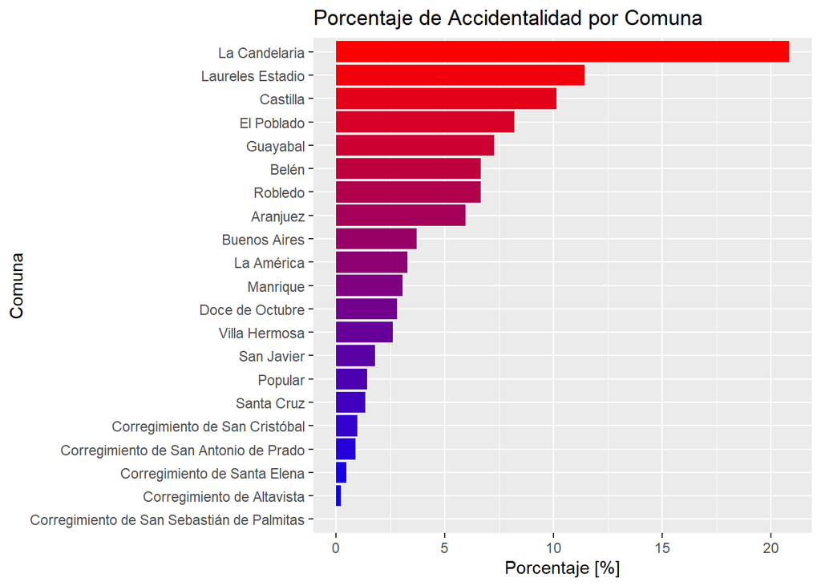

#### Distribución de la accidentalidad por barrios

Se realizo un gráfico de barras con el fin de mostrar los 22 barrios que presentan la mayor accidentalidad.

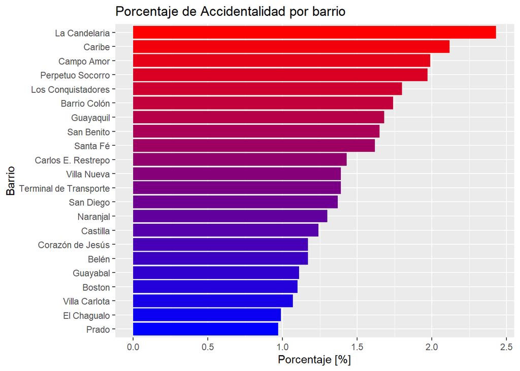

#### Distribución de la accidentalidad por mes y año

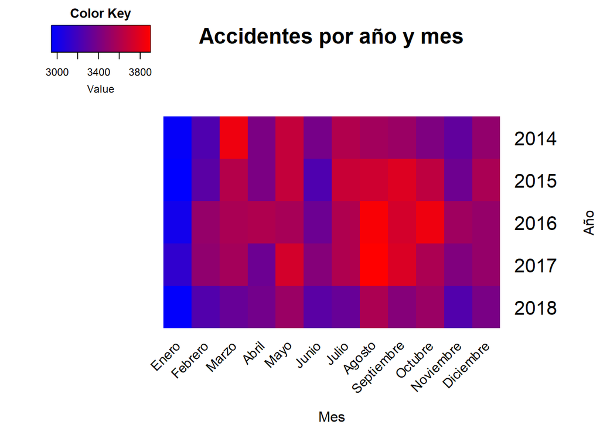

En el mes de Enero se presenta la menor cantidad de accidentes para todos los años considerados, el mes de Marzo presento una alta accidentalidad unicamente en el año 2014, en general el mes de Agosto es el mes con mayor accidentes pero fue aún más grave para los años 2016 y 2017, finalmente se observa que el mes de Octubre presento gran acidentalidad para el año 2016, los meses de Junio y Noviembre presentan comportamientos semejantes, el año con mayor cantidad de accidentes es 2016 y el año de menor accidentalidad fue 2018.

#### Distribución de la accidentalidad por mes y día

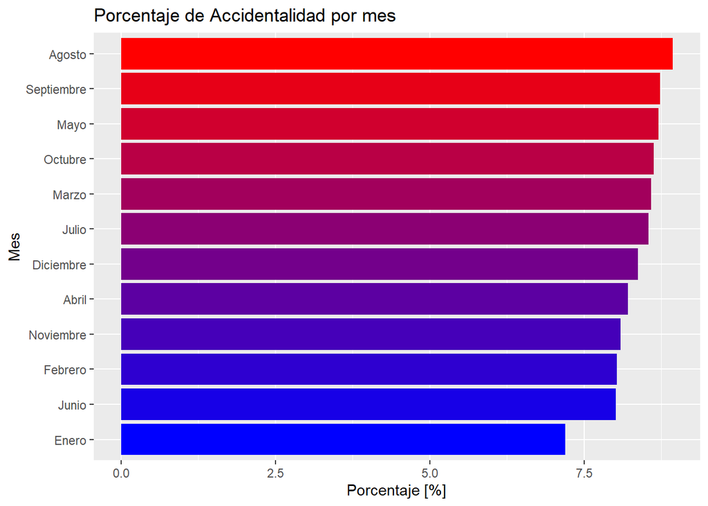

El mes que presenta mayor accidentalidad es Agosto con 8.93% cabe resaltar que este mes se derrolla la tradicional Feria de Flores de Medellín, los meses Septiembre, Mayo, Marzo, Julio y Octubre tienen un comportamiento muy similar con $\approx$ 8.6% cada uno, Noviembre, Febrero y Junio también se comportan de manera semejante con $\approx$ 8% cda uno; finalmente el mes de Enero presenta la menor cantidad de accidentes, esto puede deberse a que la mayoría de personas se encuentran fuera de la ciudad por vacaciones.

[figure not shown]

se confirma que las primeras semanas del año presentan la menor accidentalidad, los días 10 y 14 de Marzo son los más accidentados, los días 30 y 31 de Octubre se presenta gran cantodad de accidentes, entre los días 11 a 18 de Septimebre también se presenta una cantidad alta de incidentes viales esto puede deberse a las celebraciones de amor y amistad, desde el 16 al 23 de Diciembre hay fuerte accidentalidad esto se corrobora con el gráfico semanal.

#### Distribución de la accidentalidad por semana

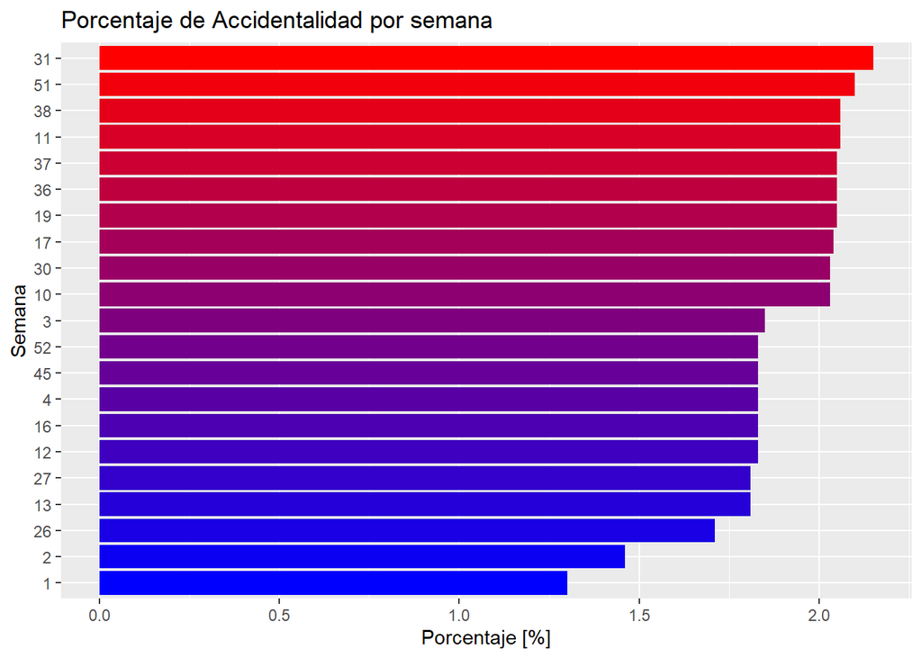

La semana 31 que va desde el 29 Julio al 05 de Agosto posee la mayor accidentalidad esto puede deberse a Feria de Flores; sigue la semana 51 comprendida entre el 17 y 23 de Diciembre, la accidentalidad presentada en esta semana puede deberse a las celebraciones de este mes, finalmente se observa que la dos primeras semanas del año son las menos accidentadas. Para este análisis se decidio juntar las semanas 52 y 53 ya que esta última solo comprendia dos días.

#### Distribución de la accidentalidad por día de la semana

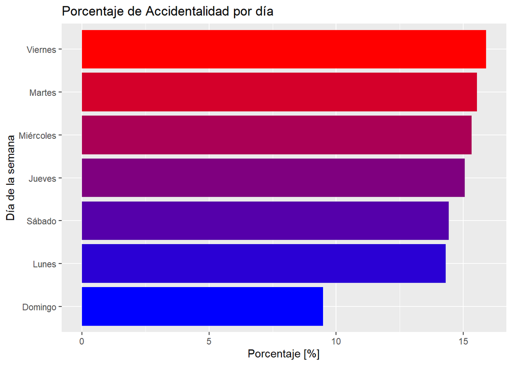

Los días Viernes y Martes se presenta la mayor cantidad de accidentes, para el día Viernes esto puede ser ocasionado por el inicio del fin de semana, repecto al día Martes se presenta un comportamiento poco esperado, se puede presentar por múltiples razones algunas de ellas los días festivos y el aforo vehicular por día. El Domingo se presenta 9.5% de accidentes, el menor de todos se siguiere que esto sucede por ser el día de descanso de la mayoría de las personas.

#### Distribución de la accidentalidad por clase

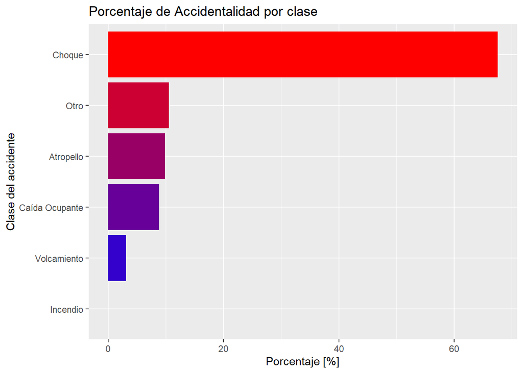

El tipo más frecuente de accidente es Choque con alrededor de 67%, Incendio representa el 0.01% del total de la población, por tanto no es significativo.

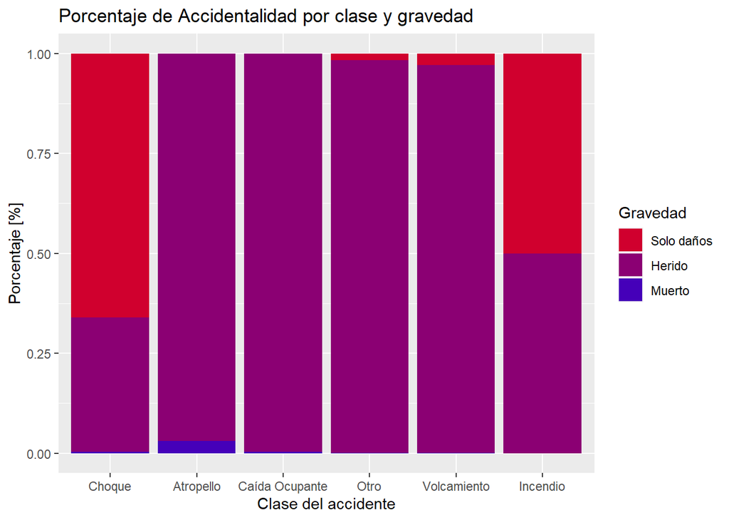

#### Distribución de la accidentalidad por diseño de vía

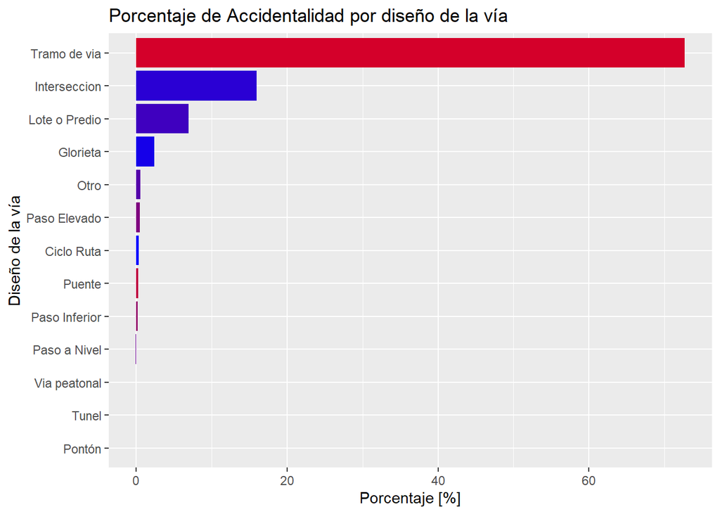

La gran parte de los accidentes en la ciudad de Medellín ocurren en Tramo de Via e Intersecciones, algo que es de esperarse ya que estas Intersecciones son de alta preligrosidad.

## Datos históricos

```r
historicos <- datos %>% group_by(PERIODO, MES_NOMBRE, MES, CLASE) %>%
  count() %>% mutate(MES=as.integer(MES))

data2014 <- historicos[historicos$PERIODO %in% c(2014), ]
data2015 <- historicos[historicos$PERIODO %in% c(2015), ]
data2016 <- historicos[historicos$PERIODO %in% c(2016), ]
data2017 <- historicos[historicos$PERIODO %in% c(2017), ]
data2018 <- historicos[historicos$PERIODO %in% c(2018), ]
```

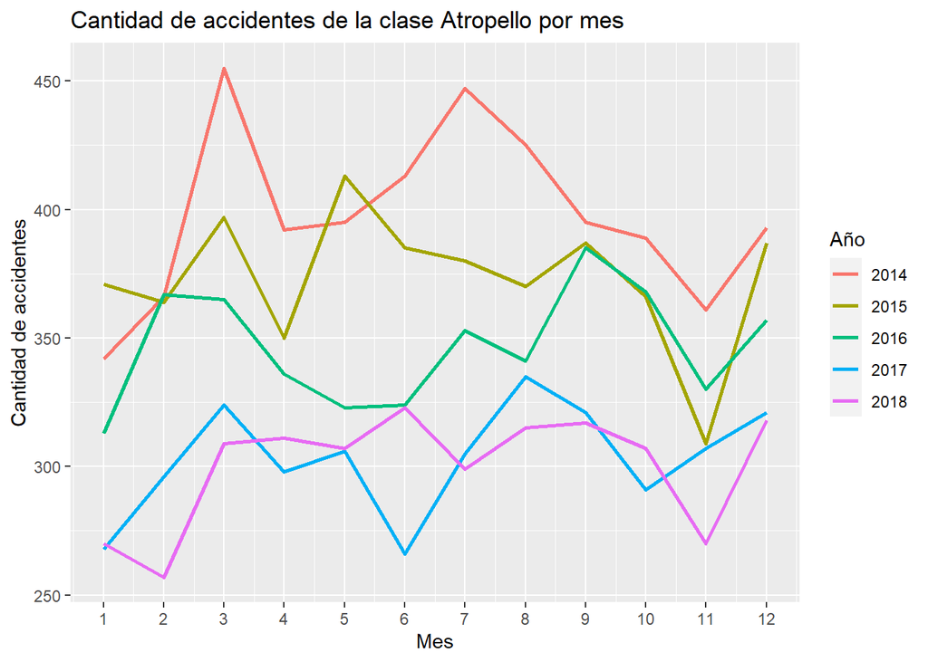

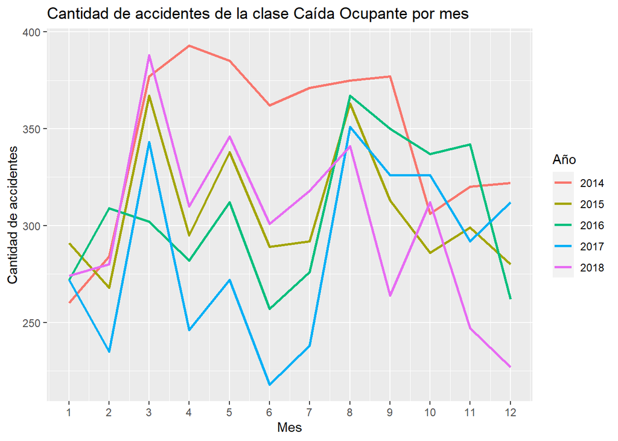

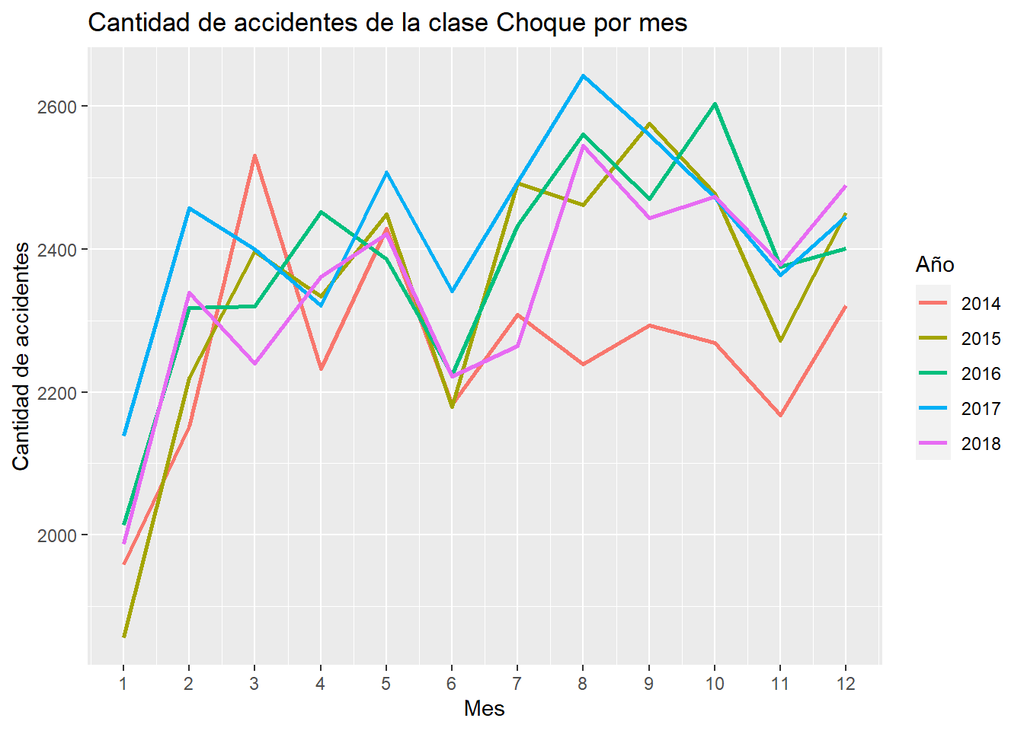

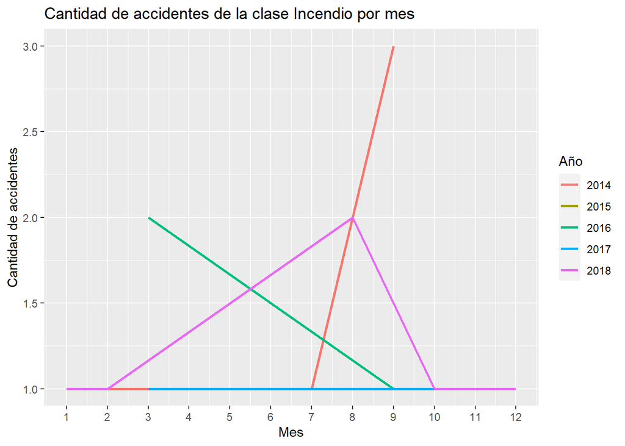

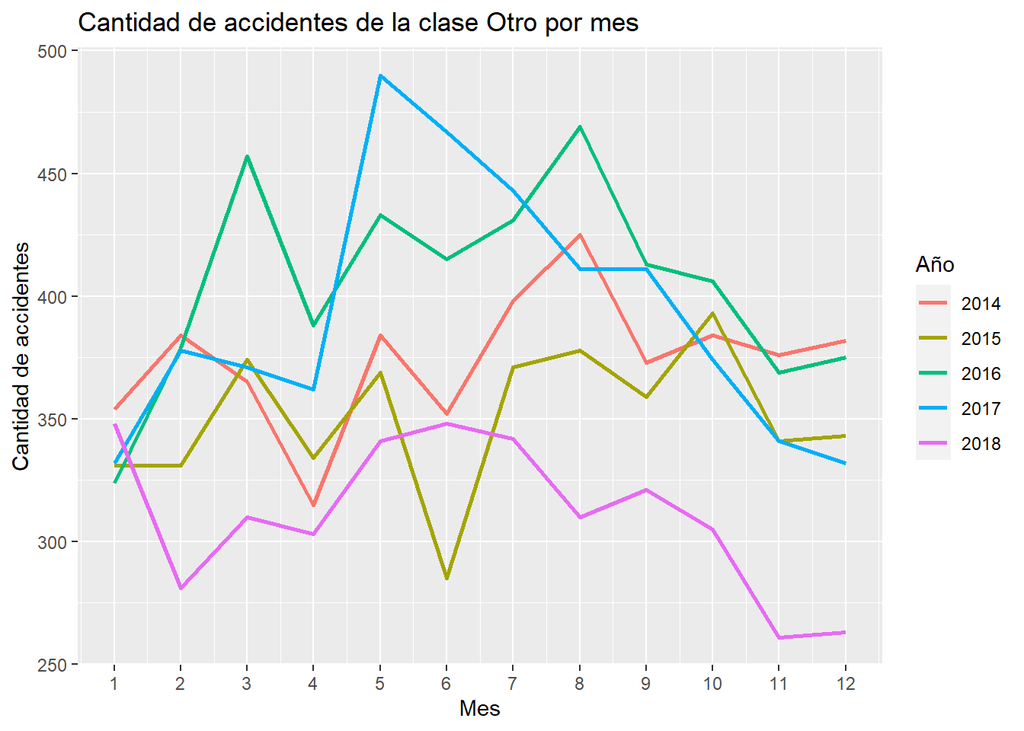

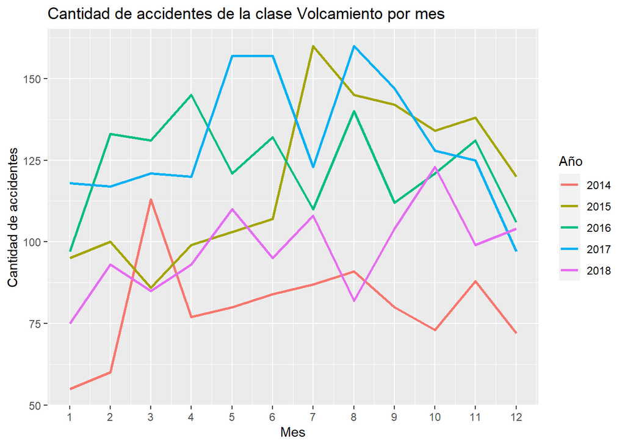

```r
for (Clase in unique(historicos$CLASE)) {
  p <- ggplot(historicos[historicos$CLASE == Clase, ],
       aes(x=MES, y=n, col=PERIODO)) +
  labs(x = "Mes", y="Cantidad de accidentes", col="Año",
       title = paste("Cantidad de accidentes de la clase", Clase, "por mes")) +
  geom_line(size = 1) +
  scale_x_continuous(breaks = seq(1,12,1))
  print(p)
}
```

## wordcloud

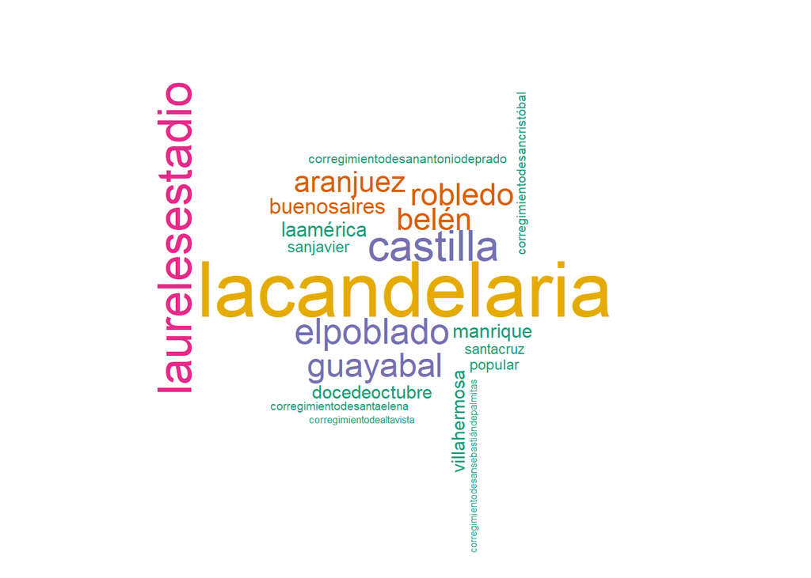

```r
datosWordC <- str_replace_all(datos$COMUNA, "\\s", "-")
wordcloud(datosWordC,colors=brewer.pal(6,"Dark2"),random.order=FALSE)
```

# Planteamiento de modelos

```r
datos_vl <- subset(datos, (PERIODO == '2018'))
datos_tr <- subset(datos, (PERIODO != '2018'))
```

# Se corre un modelo lineal teniendo en cuenta las variables de DIA_ESPECIAL, DIA_NOMBRE, DISENO

```r
# Agrupación de los datos para el modelo lineal, cada registro contiene las condiciones únicas de las 4 columnas,y se agrega la variable ded 'NRO_ACC', que son el número de accidentes cuando se cumplen esas condiciones
datos_lm1 <- datos_tr %>% group_by(FECHA, DIA_ESPECIAL, DIA_NOMBRE, DISENO) %>% count(name = "NRO_ACC")
lm1 <- lm(NRO_ACC ~ DIA_ESPECIAL+DIA_NOMBRE+DISENO, data = datos_lm1) # Modelo lineal

summary(lm1) # Se observa que el modelo lineal tiene un buen ajuste de R-cuadrado
```

```
##
## Call:
## lm(formula = NRO_ACC ~ DIA_ESPECIAL + DIA_NOMBRE + DISENO, data = datos_lm1)
##
## Residuals:
##     Min      1Q  Median      3Q     Max
## -61.206  -2.974  -1.094   3.579  67.396
##
## Coefficients:
##                     Estimate Std. Error t value Pr(>|t|)
## (Intercept)         -5.76053    0.63831  -9.025   <2e-16 ***
## DIA_ESPECIAL1       -4.88526    0.41690 -11.718   <2e-16 ***
## DIA_NOMBREJueves     8.70100    0.45025  19.325   <2e-16 ***
## DIA_NOMBRELunes      8.19571    0.44773  18.305   <2e-16 ***
## DIA_NOMBREMartes     9.22892    0.44901  20.554   <2e-16 ***
## DIA_NOMBREMiércoles  8.82445    0.45120  19.558   <2e-16 ***
## DIA_NOMBRESábado     7.82461    0.44764  17.480   <2e-16 ***
## DIA_NOMBREViernes    9.71685    0.44378  21.896   <2e-16 ***
## DISENOGlorieta       1.36790    0.62313   2.195   0.0282 *
## DISENOInterseccion  16.18131    0.61449  26.333   <2e-16 ***
## DISENOLote o Predio  5.65562    0.62536   9.044   <2e-16 ***
## DISENOOtro           0.29553    0.67840   0.436   0.6631
## DISENOPaso a Nivel   0.01768    1.62753   0.011   0.9913
## DISENOPaso Elevado  -0.75443    0.71292  -1.058   0.2900
## DISENOPaso Inferior -0.88946    0.83533  -1.065   0.2870
## DISENOPontón         0.13675    2.45669   0.056   0.9556
## DISENOPuente        -0.84636    0.75524  -1.121   0.2625
## DISENOTramo de via  86.13528    0.61445 140.182   <2e-16 ***
## DISENOTunel         -1.36174    2.59873  -0.524   0.6003
## DISENOVia peatonal  -0.05588    1.69881  -0.033   0.9738
## ---
## Signif. codes:  0 '***' 0.001 '**' 0.01 '*' 0.05 '.' 0.1 ' ' 1
##
## Residual standard error: 10.15 on 7686 degrees of freedom
## Multiple R-squared:  0.9107, Adjusted R-squared:  0.9105
## F-statistic:  4128 on 19 and 7686 DF,  p-value: < 2.2e-16
```

# El análisis de significancia obtenido por el ‘summary’ sugiere que las variables DIA_ESPECIAL, y DIA_NOMBRE son de mucha

# significancia

```r
# Se crea el conjunto de datos para la validación

lm1_2018 <- datos_vl %>% group_by(FECHA, DIA_ESPECIAL, DIA_NOMBRE, DISENO) %>% count(name = "NRO_ACC")


predicted <- round(predict(lm1, newdata=lm1_2018))
actual <- lm1_2018$NRO_ACC

lm1_mse <- MSE(predicted, actual) # MSE
lm1_mae <- MAE(predicted, actual) # MAE
lm1_r2 <- R2_Score(predicted, actual) # R2

sprintf("MSE: %f, MAE: %f, R2: %f", lm1_mse, lm1_mae, lm1_r2)
```

```
## [1] "MSE: 141.947274, MAE: 7.180518, R2: 0.750415"
```

# El primer modelo tiene buenas métricas, a excepción de la diferencia entre los R2 que indica que existe un sobre ajuste, pero #tiene un problema al tener la variable DISENO, ya que no tenemos una forma fácil de obtener esta variable para la predicción

```r
# Modelo a partir del anterior teniendo en cuenta el DIA_FESTIVO y no DÍA ESPECIAL
datos_lm2 <- datos_tr %>% group_by(FECHA,DIA_FESTIVO, DIA_NOMBRE, DISENO) %>% count(name = "NRO_ACC")
lm2 <- lm(NRO_ACC ~ DIA_FESTIVO+DIA_NOMBRE+DISENO, data = datos_lm2)

summary(lm2)
```

```
##
## Call:
## lm(formula = NRO_ACC ~ DIA_FESTIVO + DIA_NOMBRE + DISENO, data = datos_lm2)
##
## Residuals:
##     Min      1Q  Median      3Q     Max
## -54.705  -3.222  -1.112   3.673  67.346
##
## Coefficients:
##                      Estimate Std. Error t value Pr(>|t|)
## (Intercept)          -6.43113    0.62657 -10.264   <2e-16 ***
## DIA_FESTIVO1        -11.48709    0.60453 -19.002   <2e-16 ***
## DIA_NOMBREJueves      9.42618    0.44211  21.321   <2e-16 ***
## DIA_NOMBRELunes       9.95063    0.45296  21.968   <2e-16 ***
## DIA_NOMBREMartes      9.80310    0.43866  22.348   <2e-16 ***
## DIA_NOMBREMiércoles   9.32460    0.44164  21.114   <2e-16 ***
## DIA_NOMBRESábado      7.92277    0.44075  17.976   <2e-16 ***
## DIA_NOMBREViernes    10.34048    0.43596  23.719   <2e-16 ***
## DISENOGlorieta        1.41837    0.61441   2.309    0.021 *
## DISENOInterseccion   16.32826    0.60597  26.946   <2e-16 ***
## DISENOLote o Predio   5.75832    0.61663   9.338   <2e-16 ***
## DISENOOtro            0.41796    0.66894   0.625    0.532
## DISENOPaso a Nivel   -0.25563    1.60471  -0.159    0.873
## DISENOPaso Elevado   -0.75968    0.70293  -1.081    0.280
## DISENOPaso Inferior  -0.88299    0.82363  -1.072    0.284
## DISENOPontón          0.34776    2.42206   0.144    0.886
## DISENOPuente         -0.90187    0.74467  -1.211    0.226
## DISENOTramo de via   86.28252    0.60593 142.397   <2e-16 ***
## DISENOTunel          -1.75129    2.56244  -0.683    0.494
## DISENOVia peatonal    0.03184    1.67504   0.019    0.985
## ---
## Signif. codes:  0 '***' 0.001 '**' 0.01 '*' 0.05 '.' 0.1 ' ' 1
##
## Residual standard error: 10.01 on 7686 degrees of freedom
## Multiple R-squared:  0.9132, Adjusted R-squared:  0.913
## F-statistic:  4257 on 19 and 7686 DF,  p-value: < 2.2e-16
```

```r
lm2_2018 <- datos_vl %>% group_by(FECHA,DIA_FESTIVO, DIA_NOMBRE, DISENO) %>% count(name = "NRO_ACC")

predicted <- round(predict(lm2, newdata=lm2_2018))
actual <- lm2_2018$NRO_ACC

lm2_mse <- MSE(predicted, actual) # MSE
lm2_mae <- MAE(predicted, actual) # MAE
lm2_r2 <- R2_Score(predicted, actual) # R2

sprintf("MSE: %f, MAE: %f, R2: %f", lm2_mse, lm2_mae, lm2_r2)
```

```
## [1] "MSE: 141.160411, MAE: 7.300715, R2: 0.751798"
```

```r
# Modelo lineal sin la variable DISENO
datos_lm3 <- datos_tr %>% group_by(FECHA,DIA_FESTIVO, DIA_NOMBRE) %>% count(name = "NRO_ACC")
lm3 <- lm(NRO_ACC ~ DIA_FESTIVO+DIA_NOMBRE, data = datos_lm3)

summary(lm3)
```

```
##
## Call:
## lm(formula = NRO_ACC ~ DIA_FESTIVO + DIA_NOMBRE, data = datos_lm3)
##
## Residuals:
##     Min      1Q  Median      3Q     Max
## -65.214 -10.214   0.141  10.514  86.514
##
## Coefficients:
##                     Estimate Std. Error t value Pr(>|t|)
## (Intercept)           78.403      1.186   66.13   <2e-16 ***
## DIA_FESTIVO1         -54.062      2.198  -24.59   <2e-16 ***
## DIA_NOMBREJueves      45.810      1.676   27.33   <2e-16 ***
## DIA_NOMBRELunes       48.456      1.727   28.06   <2e-16 ***
## DIA_NOMBREMartes      48.313      1.678   28.80   <2e-16 ***
## DIA_NOMBREMiércoles   45.281      1.675   27.03   <2e-16 ***
## DIA_NOMBRESábado      37.688      1.676   22.49   <2e-16 ***
## DIA_NOMBREViernes     52.083      1.676   31.08   <2e-16 ***
## ---
## Signif. codes:  0 '***' 0.001 '**' 0.01 '*' 0.05 '.' 0.1 ' ' 1
##
## Residual standard error: 17.12 on 1453 degrees of freedom
## Multiple R-squared:  0.5697, Adjusted R-squared:  0.5676
## F-statistic: 274.8 on 7 and 1453 DF,  p-value: < 2.2e-16
```

# Se puede notar que el R2 Ajustado baja drásticamente al quitar la variable DISENO

```r
lm3_2018 <- datos_vl %>% group_by(FECHA,DIA_FESTIVO, DIA_NOMBRE) %>% count(name = "NRO_ACC")

predicted <- round(predict(lm3, newdata=lm3_2018))
actual <- lm3_2018$NRO_ACC

lm3_mse <- MSE(predicted, actual) # MSE
lm3_mae <- MAE(predicted, actual) # MAE
lm3_r2 <- R2_Score(predicted, actual) # R2

sprintf("MSE: %f, MAE: %f, R2: %f", lm3_mse, lm3_mae, lm3_r2)
```

```
## [1] "MSE: 273.139726, MAE: 12.750685, R2: 0.581709"
```

# Al quitar la variable las métricas de validación también empeoran

# Se intenta ahora con un modelo lineal generalizado, considerando las variables DIA_NOMBRE, DIA_FESTIVO

```r
datos_lm4 <- datos_tr %>% group_by(FECHA,DIA_FESTIVO, DIA_NOMBRE) %>% count(name = "NRO_ACC")
lm4 <- glm(NRO_ACC ~ DIA_FESTIVO+DIA_NOMBRE, family = "poisson", data = datos_lm4) # Modelo lineal generalizado, con familia poisson
summary(lm4)
```

```
##
## Call:
## glm(formula = NRO_ACC ~ DIA_FESTIVO + DIA_NOMBRE, family = "poisson",
##     data = datos_lm4)
##
## Deviance Residuals:
##     Min       1Q   Median       3Q      Max
## -6.5627  -0.9429   0.0081   0.9522   6.8943
##
## Coefficients:
##                      Estimate Std. Error z value Pr(>|z|)
## (Intercept)          4.355791   0.007880  552.78   <2e-16 ***
## DIA_FESTIVO1        -0.577975   0.014947  -38.67   <2e-16 ***
## DIA_NOMBREJueves     0.466393   0.010071   46.31   <2e-16 ***
## DIA_NOMBRELunes      0.490270   0.010333   47.45   <2e-16 ***
## DIA_NOMBREMartes     0.486222   0.010005   48.60   <2e-16 ***
## DIA_NOMBREMiércoles  0.461964   0.010046   45.99   <2e-16 ***
## DIA_NOMBRESábado     0.398583   0.010164   39.22   <2e-16 ***
## DIA_NOMBREViernes    0.516556   0.009971   51.81   <2e-16 ***
## ---
## Signif. codes:  0 '***' 0.001 '**' 0.01 '*' 0.05 '.' 0.1 ' ' 1
##
## (Dispersion parameter for poisson family taken to be 1)
##
##     Null deviance: 9160  on 1460  degrees of freedom
## Residual deviance: 3720  on 1453  degrees of freedom
## AIC: 13317
##
## Number of Fisher Scoring iterations: 4
```

```r
lm4_2018 <- datos_vl %>% group_by(FECHA,DIA_FESTIVO, DIA_NOMBRE) %>% count(name = "NRO_ACC")

predicted <- round(predict(lm4, newdata=lm4_2018, type="response")) # Se usa type= 'response' por ser una regresion logística
actual <- lm4_2018$NRO_ACC

lm4_mse <- MSE(predicted, actual) # MSE
lm4_mae <- MAE(predicted, actual) # MAE
lm4_r2 <- R2_Score(predicted, actual) # Pseudo R2

sprintf("MSE: %f, MAE: %f, Pseudo R2: %f", lm4_mse, lm4_mae, lm4_r2)
```

```
## [1] "MSE: 272.720548, MAE: 12.753425, Pseudo R2: 0.582351"
```